# Multiple linear regression: statistical framework

# Multiple linear regression: the statistical framework

## What will we learn in this empirical example ?

1. How to perform a statistical test in a multiple linear regression framework.
2. How to compare different models using the Fisher test.
3. How to informally test and relax the normality assumption.

## Theory behind the empirical exercise

In this short document, we carry on the exercise on the two trading strategies of chartists (see the empirical exercise on the mathematical framework of the multiple linear regression for more information). As we did in the previous exercise, We still consider a moving average with $s=2$ and $l=12$ and a momentum strategy with $l=9$. The buying (and selling) orders of the two strategies can be correlated so we consider a multiple linear regression to test them jointly. Given monthly returns $y_t$, we estimate the multiple linear regression,

$$y_t = \beta_1 + \beta_2 S(s,l)_t + \beta_3 \text{Mom}(l)_t + \beta_4 \text{Mom}(l)_t S(s,l)_t + \epsilon_t.$$
The cross-product variable $\text{Mom}(l)S(s,l)$ stands as the strategy of buying the asset when both MA and Momentum strategies give a buying signal. The other coefficients $\beta_2$ and $\beta_3$ can be interpreted as the returns of applying the MA or the Momentum strategy when the two signals diverge.

For IBM returns, we have seen that the cross-product strategy seems effective (i.e. $\beta_4>0$). In this exercise, we shall test if the strategy is significantly different from zero.

## From theory to practice

We first load the dependent variable and create the explanatory variables using the IBM prices.

```python
import matplotlib.pyplot as plt
import pandas as pd
import numpy as np
import statsmodels.api as sm
import scipy.stats as stats
url="https://raw.githubusercontent.com/adufays/GDP_expectancy/main/IBM.csv"
data = pd.read_csv(url,sep=",")


price  = np.array(data.Close)
date = data.Date


def MA_strat(price,s):
    T = np.size(price)
    MA = np.zeros([T,1])
    for t in range(s-1,T):
        MA[t] = np.mean(price[(t-s+1):(t+1)])

    return(MA)


MA_long_term = MA_strat(price,12)
MA_short_term = MA_strat(price,2)

tech_MA = MA_short_term>MA_long_term


def Momentum(price,s):
    T = np.size(price)
    Mom = np.zeros([T,1])
    for t in range(s,T):
        Mom[t] = price[t]>=price[(t-s)]

    return(Mom)

tech_MOM = Momentum(price,9)

T = np.size(price)
K = 4
IBM_ret = np.zeros([T,1])
IBM_ret[0:(T-1),0] = 100*(price[1:T]-price[0:(T-1)])/price[0:(T-1)]

X = np.zeros([T,4])
y = IBM_ret
X[:,0] = 1
X[:,1:4] = np.hstack((tech_MA,tech_MOM,tech_MA*tech_MOM))
```

We now create a function that compute the OLS estimates, the t-statistics (for the Null hypotheses $\beta_i=0~~i\in[1,K]$), the corresponding p-values, the coefficient of determination. The function also computes the Fisher test by comparing the unrestricted model with a model exhibiting a constant. The underlying assumption of this Fisher test is as follows,

$$H_0: \beta_2=\ldots=\beta_K=0 \text{ vs } H_1: \text{at least one } \beta_i \neq 0~~\text{ with } i \in [2,K].$$

```python
def OLS_computation(y,X):
    K = np.size(X,1)
    T = np.size(y)
    XprimeX=np.matmul(np.transpose(X),X)
    XprimeXinv=np.linalg.inv(XprimeX)
    beta_ols=np.matmul(XprimeXinv,np.matmul(np.transpose(X),y))
    epsi = y - np.matmul(X,beta_ols)
    sigma_hat = sum(epsi**2)/(T-K)
    beta_var = np.diag(sigma_hat*XprimeXinv)
    t_stat = np.divide(np.transpose(beta_ols),np.sqrt(beta_var))
    p_val = 2*(1-stats.t.cdf(np.abs(t_stat),T-K))
    data_frame =pd.DataFrame(np.transpose(np.vstack(((np.transpose(beta_ols),np.sqrt(beta_var),t_stat,p_val)))),columns=["Estimate","Std.Error","t_value","Pr(>|t|)"])

    SSR_U = sum(epsi**2)
    SSR_R = sum((y-np.mean(y))**2)
    R_sq = 1-SSR_U/SSR_R
    df1 = K-1
    df2 = T-K
    F_test = (df2/df1)*(SSR_R-SSR_U)/SSR_U
    F_p_val = (1-stats.f.cdf(F_test,df1,df2))

    data_frame_fisher=pd.DataFrame(np.transpose(np.asarray((F_test,F_p_val))),columns=["F_stat","P value"])
    df_r_sq = pd.DataFrame(R_sq,columns=["R-squared"])
    df_residuals = pd.DataFrame(epsi,columns=["Residuals"])
    return(data_frame,data_frame_fisher,df_r_sq,df_residuals)
```

By running the function *OLS_computation* with the IBM returns as the dependent variable, we get the following results:

```python
result  = OLS_computation(y,X)
print(result[0])
```

```
##    Estimate  Std.Error   t_value  Pr(>|t|)
## 0  0.815606   0.441300  1.848188  0.064996
## 1 -0.931835   1.105596 -0.842835  0.399608
## 2 -0.724435   1.270923 -0.570007  0.568855
## 3  1.498966   1.664617  0.900487  0.368170
```

```python
print(result[1])
```

```
##      F_stat   P value
## 0  0.309707  0.818384
```

```python
print(result[2])
```

```
##    R-squared
## 0   0.001322
```

First, we observe that the fourth parameter equals 1.498 and is positive. Its t-statistics amounts 0.90. This statistic (in absolute value) is smaller that 1.64 (significant level of 90%) or 1.96 (significant level of 95%). So, we do not reject the Null hypothesis of $\beta_4=0$. The p-value is also very high (and, of course, higher than 0.1). We can conclude that we should not use this mixed strategy as its returns are not significantly different from zero. By looking to the other t-statistics, we also conclude that none of these strategies lead to significant changes. We can also have a look to the p value of the Fisher test. Again, it is higher than standard thresholds like 0.1 or 0.05. We conclude that this model is not statistically different from a model with a constant only. To end this exercise, we compare the output of our function *OLS_computation* with the one of Python.

```python
model_OLS=sm.OLS(y,X).fit()
print(model_OLS.summary())
```

```
##                             OLS Regression Results
## ==============================================================================
## Dep. Variable:                      y   R-squared:                       0.001
## Model:                            OLS   Adj. R-squared:                 -0.003
## Method:                 Least Squares   F-statistic:                    0.3097
## Date:                Fri, 07 May 2021   Prob (F-statistic):              0.818
## Time:                        14:12:16   Log-Likelihood:                -2368.5
## No. Observations:                 706   AIC:                             4745.
## Df Residuals:                     702   BIC:                             4763.
## Df Model:                           3
## Covariance Type:            nonrobust
## ==============================================================================
##                  coef    std err          t      P>|t|      [0.025      0.975]
## ------------------------------------------------------------------------------
## const          0.8156      0.441      1.848      0.065      -0.051       1.682
## x1            -0.9318      1.106     -0.843      0.400      -3.103       1.239
## x2            -0.7244      1.271     -0.570      0.569      -3.220       1.771
## x3             1.4990      1.665      0.900      0.368      -1.769       4.767
## ==============================================================================
## Omnibus:                       39.715   Durbin-Watson:                   2.029
## Prob(Omnibus):                  0.000   Jarque-Bera (JB):              113.748
## Skew:                           0.209   Prob(JB):                     1.99e-25
## Kurtosis:                       4.921   Cond. No.                         12.2
## ==============================================================================
##
## Warnings:
## [1] Standard Errors assume that the covariance matrix of the errors is correctly specified.
```

We now test our linear regression assumptions. First, we question the normality assumption of the residuals. To do so, we use a QQ-plot to see how the quantiles of the standardized residuals differ from the quantiles of a standard Normal distribution.

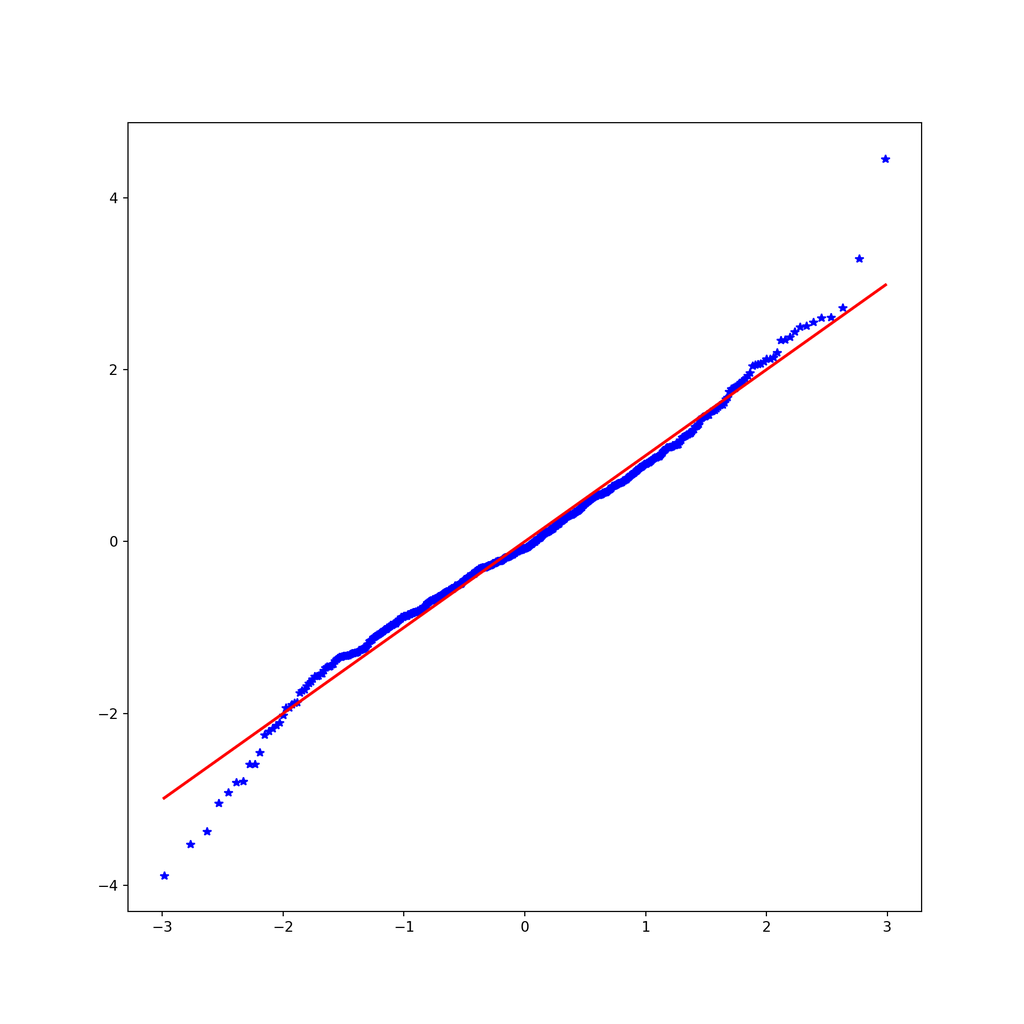

```python
epsi = np.array(result[3])
sigma_hat = sum(epsi**2)/(T-K)
epsi_sorted = np.sort(epsi/np.sqrt(sigma_hat),axis=0)
quant = np.linspace(1/T, 1,num=T)
quantile_norm = stats.norm.ppf(quant)

fig, ax = plt.subplots(figsize=(10, 10))
plt.plot(quantile_norm,epsi_sorted,'*',color="blue")
plt.plot(quantile_norm,quantile_norm,'-r',linewidth=2)
plt.show()
```

As we observe on the QQ-plot, there are slight deviations at the tails. However, since the returns are stationary and our sample size is large enough, our OLS estimators is normally distributed (when a CLT applies) even if the residuals are not normally distributed.